# Figure 5 hyper gate

Read in the annotated dataset

```r
library(Seurat)
library(dplyr)
library(ggplot2)
library(reshape2)
library(hypergate)

# output path for data objects
outpath <- "/Users/rhalenathomas/Documents/Data/FlowCytometry/PhenoID/Analysis/PaperFigures/"
# output path for figures
output_path <- "/Users/rhalenathomas/Documents/Projects_Papers/PhenoID/ForFigures/"

seu <- readRDS(paste(outpath,"seuAllcells.15072022.Rds"))
```

Run hypergate

```r
# set the identity to the labels to by the hypergate input
Idents(seu) <- 'cell.types'

# down sample
i = 800
set.seed(i)
seu.down <- subset(x= seu, downsample = i)
DimPlot(seu.down)
table(seu.down$cell.types)

# create a matrix to be the input for hypergate
input.xm = as.matrix(GetAssayData(seu.down, slot = 'data'))
xm.t <- t(input.xm)
cluster.labels <- as.vector(seu.down$cell.types)
```

Run hypergate

```r
# make a vector of all the cells to gate

# first I will gate with all cell types
# the number of cells included will alter the gates

cell.types <- c("Astrocytes 1", "Astrocytes 2","Radial Glia 1","Radial Glia 2",
                     "Epithelial","Endothelial","NPC","Neurons 1","Neurons 2",
                     "Oligodendrocytes","OPC","Stem cell like",
                "Glia Lineage","Neural Lineage")

# run gating and get the output
for (cell in cell.types) {
  hg_output <- hypergate(xp = xm.t, gate_vector = cluster.labels, level = cell)
  gating_predicted = subset_matrix_hg(hg_output,xm.t)
  conf.table <- table(ifelse(gating_predicted, "Gated-in", "Gated-out"), ifelse(cluster.labels ==  cell, cell, "Others"))
  print(cell)
  print(conf.table)
  print(hgate_rule(hg_output))

}


saveRDS(seu, (paste(outpath,"All9MOannaote.12072022.Rds")))
```

Merge together all the same cell types and see if accuracy is altered

```r
# I need to make neurons 1 neurons 2 Glia 1 and Glia2

# regroups all RG and all astro and check the accuracy
# these were are the cell type labels in
Idents(seu.q) <- "seurat_clusters"
cluster.ids <- c("Glia Lineage","Neural Lineage","Radial Glia 1","Epithelial","Neurons 1",
                 "Radial Glia 2","Astrocytes 1","Astrocytes 1","Neurons 1","Radial Glia 2",
                 "Astrocytes 2","Radial Glia 1","Endothelial","Stem cell like","Neurons 1",
                 "Astrocytes 1","NPC","Neurons 2","Neurons 2","Astrocytes 1",
                 "Neurons 2","Astrocytes 1","Epithelial","Astrocytes 2","Epithelial",
                 "Radial Glia 2","Astrocytes 1","Neurons 2","Oligodendrocytes","Stem cell like",
                 "NPC","NPC","Astrocytes 2","Endothelial","OPC",
                 "Astrocytes 2")


# merge all the RG and merge all the astrocytes
# keep neurons, npc, oligo
# make all the other cells as 'other'

Idents(seu) <- "seurat_clusters"
cluster.ids <- c("ot","ot","Radial Glia","ot","Neurons 1",
                 "Radial Glia","Astrocytes","Astrocytes","Neurons 1","Radial Glia",
                 "Astrocytes","Radial Glia","ot","ot","Neurons 1",
                 "Astrocytes","NPC","Neurons 2","Neurons 2","Astrocytes",
                 "Neurons 2","Astrocytes","ot","Astrocytes","ot",
                 "Radial Glia","Astrocytes","Neurons 2","Oligodendrocytes","ot",
                 "NPC","NPC","Astrocytes","ot","ot",
                 "Astrocytes")



names(cluster.ids) <- levels(seu)
seu <- RenameIdents(seu, cluster.ids)
seu$gating.groups1 <- Idents(seu)

Idents(seu) <- 'gating.groups1'

# down sample
i = 1000
set.seed(i)
seu.down <- subset(x= seu, downsample = i)
DimPlot(seu.down)
table(seu.down$cell.types)

DimPlot(seu.down)

# create a matrix to be the input for hypergate
input.xm = as.matrix(GetAssayData(seu.down, slot = 'data'))
xm.t <- t(input.xm)
cluster.labels <- as.vector(seu.down$gating.groups1)

table(seu.down$gating.groups1)


cell.types <- c("Astrocytes","Radial Glia","NPC","Neurons 1","Neurons 2",
                     "Oligodendrocytes","ot")

# run gating and get the output
for (cell in cell.types) {
  hg_output <- hypergate(xp = xm.t, gate_vector = cluster.labels, level = cell)
  gating_predicted = subset_matrix_hg(hg_output,xm.t)
  conf.table <- table(ifelse(gating_predicted, "Gated-in", "Gated-out"), ifelse(cluster.labels ==  cell, cell, "Others"))
  print(cell)
  print(conf.table)
  print(hgate_rule(hg_output))

}
```

Read in the gated populations made in FlowJo from the hyper gates

```r
# preprocess the data
library("flowCore") #Used for reading the data
library("ggplot2")
require("stringr") #set of functions to manipulate strings type in order to have nice titles
library("rlist") #set of functions that allows to easely manipulate lists
library("reshape2") #visualization
library("flowStats") #Alignment functions
library("scales") #scale colour intensity for visualization
library("dplyr")
#libraries
library("flowCore")



input_path <- "/Users/rhalenathomas/Documents/Data/FlowCytometry/PhenoID/Analysis/PaperFigures/GatingPopulations/gatedPopulations/"
output_path <- "/Users/rhalenathomas/Documents/Data/FlowCytometry/PhenoID/Analysis/PaperFigures/GatingPopulations/"

write_fcs_files <- TRUE #Set to true to write fcs files at each step (subsampled, transformed, aligned and scaled) - recommanded

#Create output folder if it's not already created
if(dir.exists(output_path)==FALSE){ #check
  dir.create(output_path) #create directory
}


flowset <- read.flowSet(path=input_path,transformation = FALSE ,emptyValue = FALSE,truncate_max_range = FALSE, package="flowCore") #Create a flowset object
flowsetold <- read.flowSet(path="/Users/rhalenathomas/Documents/Data/FlowCytometry/PhenoID/FlowDataFiles/9MBO",transformation = FALSE ,emptyValue = FALSE,truncate_max_range = FALSE, package="flowCore")

flowset <- fsApply(flowset,function(x){x[ ,grepl("^[{'FJComp'}|{'FCS'}|{'SSC'}].*A$",colnames(flowset))]}) #Apply a function to flowSet (fsApply) that selects only the columns corresponding to areas values using "regular expression".



sampleNames(flowset)
```

```
[1] "concat_1_Astrocyte.fcs"        "concat_1_endothelial.fcs"      "concat_1_epithelial.fcs"
[4] "concat_1_Neurons1.fcs"         "concat_1_Neurons2.fcs"         "concat_1_NPC2.fcs"
[7] "concat_1_oligodendrocytes.fcs" "concat_1_RadialGLia.fcs"       "concat_1_stemcell.fcs"
```

```r
sampleNames(flowset) <- c("Astrocytes","Endothelial","Epithelial","Neurons1","Neurons2","NPC",
                          "Oligodendrocytes","RadialGlia","StemCellLike") #directly modify the names inside the flowset
sampleNames(flowset)
```

```r
# run the functions in the preprocessing scripts. These will be in a library
# thisi s the function to save

flowset_to_csv(flowset)#apply the function
```

```r
# read back in the flowset csv to create a new seurat object

df <- read.csv("/Users/rhalenathomas/Documents/Data/FlowCytometry/PhenoID/Analysis/PaperFigures/GatingPopulations/flowset.csv")
df2 <- df %>% dplyr::select(c("CD24","CD56","CD29","CD15","CD184","CD133","CD71","CD44","GLAST","AQP4","HepaCAM", "CD140a","O4"))
m <- as.matrix(df2)
# create the seurat object for visualization
tm <- t(df2)
rownames(tm) <- colnames(df2)
colnames(tm) <- rownames(df2)
seu <- CreateSeuratObject(tm)
# for later to see features we define the vector here
AB <- colnames(df2)
# add the sample names into the seurat object
seu <- AddMetaData(object=seu, metadata=df$Batch, col.name = 'GatedPop')
# prepare object to cluster
# prepare the object for clustering

table(seu$GatedPop)

seu <- ScaleData(seu)
# 231143 cells

seu <- RunPCA(seu, features = AB, npcs = 12, approx = FALSE)
seu <- FindNeighbors(seu, dims = 1:12, k.param =60)
seu <- RunUMAP(seu, dims = 1:12, n.neighbors = 60, spread = 2, a=0.54,b=0.84, min.dist = 0.5)

seu <- FindClusters(seu, resolution = c(0.5,0.9,1.2))

outpath <- "/Users/rhalenathomas/Documents/Data/FlowCytometry/PhenoID/Analysis/PaperFigures/"
saveRDS(seu,paste(outpath,"FlowJogatedSeu.Rds"))

###  Now to visualize the cell types

DimPlot(seu, group.by = 'GatedPop')




# plot saving path
out_plots <- "/Users/rhalenathomas/Documents/Projects_Papers/PhenoID/ForFigures/"


png(paste(out_plots,"NewFeaturePLotsFlowJO.png"), width = 1200, height = 500)
FeaturePlot(seu, features = AB, slot = 'scale.data',min.cutoff = 'q3', max.cutoff ='q97')
dev.off()



Idents(seu) <- 'RNA_snn_res.1.2'
DimPlot(seu)
DimPlot(seu, group.by = 'GatedPop')

### make a UMAP of the gated in cell types


# change the order of the cell types on the legend of the umap
cell.type.order <- c("Astrocytes", "RadialGlia",
                     "Epithelial","Endothelial","NPC","Neurons1","Neurons2",
                     "Oligodendrocytes","StemCellLike")
cell.type.order <- rev(cell.type.order)
clust.colours <- c("chocolate1", "pink",
                   "steelblue3","deepskyblue","plum3","purple","orchid2",
                   "seagreen3","tomato3")


Idents(seu) <- 'GatedPop'
pdf(paste(out_plots,"UMAP.flowjo.gated.pop.pdf"),width = 12, height = 6)
DimPlot(seu, order = cell.type.order, cols = clust.colours, shuffle = TRUE, raster=FALSE,pt.size = 0.01, label = FALSE) +
  theme(legend.text = element_text(size=20), axis.title.y = element_text(size=20),
        axis.title.x = element_text(size=20), axis.text.y = element_text(size =20),
        axis.text.x = element_text(size =20))
dev.off()


Idents(seu) <- 'seurat_clusters'
png(paste(out_plots,"UMAP.flowjo.gated.pop.seuratecluster.png"),width = 1200, height = 500)
DimPlot(seu,shuffle = TRUE, raster=FALSE,pt.size = 0.1, label = FALSE)+
  theme(legend.text = element_text(size=20), axis.title.y = element_text(size=20),
        axis.title.x = element_text(size=20), axis.text.y = element_text(size =20),
        axis.text.x = element_text(size =20))
dev.off()

png(paste(out_plots,"HM.flowjo.gated.pop.seuratecluster.png"),width = 1200, height = 500)
DoHeatmap(seu, group.by = "seurat_clusters", features = AB, size= 6,slot = "scale.data", disp.max = 2, disp.min = -1.5) + scale_fill_gradientn(colors = c("#154c79", "#eeeee4", "#e28743")) +
  theme(axis.text.y = element_text(size = 12))
dev.off
```

Annotate the dataset of FlowJo gated files from hypergate

```r
DimPlot(seu.r)
```

Add the annotation for the cell types and then I can look at which cell types are in each original input

```r
Idents(seu) <- "seurat_clusters"
cluster.ids <- c("Astro1","Neur1","Astro1","Neur2","Astro2",
                 "RG1",
                 "RG2","stem","stem","NPC","Neur2","epi1","epi2","Neur2","Astro2",
                 "Neur1","endo1","Neur2","Neur1","Neur1","RG1","NPC","Astro1",
                 "epi3","oligo","endo2","oligo"
                  )

names(cluster.ids) <- levels(seu)
seu<- RenameIdents(seu, cluster.ids)
seu$labels1 <- Idents(seu)

DimPlot(seu, reduction = "umap", label = TRUE, group.by = 'labels1', repel = TRUE)
DimPlot(seu, reduction = "umap", label = TRUE, group.by = 'seurat_clusters', repel = TRUE)


Idents(seu) <- "seurat_clusters"
cluster.ids <- c("Astrocytes 1","Neurons 1","Astrocytes 1","Neurons 2",
                 "Astrocytes 2","Radial Glia 1","Radial Glia 2",
                 "Stem cell like","Stem cell like","NPC","Neurons 2",
                 "Endothelial","Endothelial","Neurons 2","Astrocytes 2",
                 "Neurons 1","Epithelial","Neurons 2","Neurons 1",
                 "Neurons 1","Radial Glia 1","NPC","Astrocytes 1",
                 "Endothelial","Oligodendrocytes","Epithelial","Oligodendrocytes"
                  )

names(cluster.ids) <- levels(seu)
seu<- RenameIdents(seu, cluster.ids)
seu$cell.ids <- Idents(seu)

DimPlot(seu,label = TRUE, repel = TRUE, group.by = 'cell.ids')
```

Get the count of these cell types in each of the gated groups.

```r
# make the plots and the prediction tables
t.lables <- as.data.frame(table(seu$GatedPop,seu$cell.ids))
pr.t.lables <- as.data.frame(prop.table(table(seu$GatedPop,seu$cell.ids)))
t.lables$Freq <- as.double(t.lables$Freq)


# try bar chart
ggplot(t.lables, aes(y = Freq, x = Var1, fill = Var2)) + geom_bar(position = "stack", stat= "identity")

clust.colours <- c("chocolate1","orange","lightsalmon", "pink",
                   "steelblue3","deepskyblue","plum3","purple","orchid2",
                   "seagreen3","tomato3")

df <- pr.t.lables

cell.type.order <- c("Astrocytes 1", "Astrocytes 2","Radial Glia 1","Radial Glia 2",
                     "Epithelial","Endothelial","NPC","Neurons 1","Neurons 2",
                     "Oligodendrocytes","Stem cell like")

cell.type.order <- rev(cell.type.order)
colnames(df) <- c("GatedCells","PhenoID.CellTypes","Freq")

df <- df %>% mutate(PhenoID.CellTypes = factor(PhenoID.CellTypes, levels= cell.type.order))

###### Figure 5B #####

pdf(paste(out_plots,"Bar.FlowJoGated.phenoID.prop.pdf"),width = 8, height = 6)
ggplot(df, aes(x = GatedCells, y=Freq ,fill = PhenoID.CellTypes)) + geom_bar(position= "fill", stat = "identity")  +
  RotatedAxis() +
  scale_y_continuous(labels = scales::percent_format()) + theme_classic() + theme(text = element_text(size=18),
        axis.text.x = element_text(angle=90, hjust=1, size = 18))  + xlab('Gated cell types') + ylab('Proportion of cell type')  + scale_fill_manual(values = clust.colours) + guides(fill=guide_legend(title="PhenoID cell type annotations"), element_text(size = 18))
dev.off()

# find the top 2 in cell in the group

top.labs <- t.lables  %>% group_by(Var1)  %>% top_n(3, Freq)
top.labs

top.lab <- t.lables  %>% group_by(Var1)  %>% top_n(1, Freq)
top.lab
```

New data from May 10th, 2022 Populations sorted after the FACS gating the some cell acquired

```r
flowset <- fsApply(flowset,function(x){x[ ,grepl("^[{'FITC'}|{'FCS'}|{'SSC'}|{'PerCP'}|{'PE'}|{'APC'}|{'BV'}].*A$",colnames(flowset))]}) #Apply a function to flowSet (fsApply) that selects only the columns corresponding to areas values using "regular expression".

sampleNames(flowset)
```

```
[1] "2022-05-10_post_sort_tris_glia1.fcs"   "2022-05-10_post_sort_tris_glia2.fcs"
[3] "2022-05-10_post_sort_tris_neuron1.fcs" "2022-05-10_post_sort_tris_neuron2.fcs"
```

```r
head(flowset@frames$`2022-05-10_post_sort_tris_glia1.fcs`)
```

```
        FSC-A     SSC-A  FITC-A PerCP-Cy5-5-A    PE-A PE-Texas Red-A PE-Cy7-A   APC-A
[1,] 24264.44  47068.38 2019.77        119.90  167.28         108.24   493.64  312.18
[2,] 30935.92  22409.31  171.13       5569.90  330.46         510.04  2048.36 1101.54
[3,] 78258.48  98714.77  571.16        390.22  346.04         378.02   984.00  585.42
[4,] 61081.68 101827.80  516.66       2319.52  287.82         268.14   283.72  372.90
[5,] 50692.64 111741.35 1789.78       1282.93 1339.06        1370.22   195.16  366.96
[6,] 53182.80 112065.09 1097.63       1101.99 1451.40        1343.16   154.16  309.54
     Alexa Fluor 700-A APC-Cy7-A  BV421-A  BV510-A  BV605-A BV650-A BV711-A   BV786-A
[1,]          108.2400  675.1801  1246.08  1072.50  1915.98  778.14  126.72  437.5800
[2,]          850.7401 3211.5601 11994.18  1945.68  6653.46 3653.10 3220.80 3439.2603
[3,]          293.0400 1945.6801 20424.36  3524.40  6780.18 6880.50 1247.40 1397.8800
[4,]          365.6400  443.5200 20519.40  3402.96  5833.74 2579.94 2498.10 1652.6400
[5,]          243.5400  180.8400  3049.20 13530.66 22773.96 6103.68 1272.48  823.6801
[6,]          135.9600   40.9200  3103.98 14559.60 24928.20 7675.14 1210.44  706.2000
```

```r
sampleNames(flowset) <- c("Astrocytes","RadialGlia","Neurons1","Neurons2") #directly modify the names inside the flowset
sampleNames(flowset)
```

```
[1] "Astrocytes" "RadialGlia" "Neurons1"   "Neurons2"
```

```r
rename_markers<-function(flowset){#Defines a function to use marker names
  copy_flowset=flowset[seq(along=flowset)]
  for (i in 1:length(copy_flowset)){
    marker.names=copy_flowset[[i]]@parameters@data$desc
    marker.names=lapply(marker.names,function(x){str_replace_all(x,"-","_")})
    colnames(copy_flowset[[i]]@exprs)<-unlist(lapply(marker.names, function(x){sapply(str_split(x,"_"),head,1)}))
  }
  return(copy_flowset)
}

# saving function
flowset_to_csv=function(flowset){
  list_of_flowframes=fsApply(rename_markers(flowset),function(x){as.data.frame(x@exprs)})#Makes a list of dataframes
  list_names=names(list_of_flowframes)#extract names for not calling names() function at each loop
  for (index in seq_along(list_of_flowframes)){ #Iterates along the index for adding sample names
    list_of_flowframes[[index]]$Sample = list_names[index]
    colnames(list_of_flowframes[[index]]) = colnames(list_of_flowframes[[1]])
  }
  ds=list.rbind(list_of_flowframes)#binds every fcs file in a single dataframe
  ds$cell=as.factor(unlist(lapply(as.list(c(1:length(flowset))),function(x){c(1:nrow(flowset[[x]]@exprs))})))#add cell IDs - cell count per sample
  write.csv(ds,file=paste0(output_path,deparse(substitute(flowset)),".csv"))#save the R data for further usage
}



may10 <- flowset

flowset_to_csv(may10)#apply the function
```

Read the csv data from flowset back in

```r
df2 <- df.may10 %>% dplyr::select(c("CD24","CD56","CD29","CD15","CD184","CD133","CD71","CD44","GLAST","AQP4","HepaCAM", "CD140a","O4"))
m <- as.matrix(df2)
# create the seurat object for visualization
tm <- t(df2)
rownames(tm) <- colnames(df2)
colnames(tm) <- rownames(df2)
seu <- CreateSeuratObject(tm)
# for later to see features we define the vector here
AB <- colnames(df2)
# add the sample names into the seurat object
seu <- AddMetaData(object=seu, metadata=df.may10$Sample, col.name = 'GatedPop')
# prepare object to cluster
# prepare the object for clustering

table(seu$GatedPop)
```

```
Astrocytes   Neurons1   Neurons2 RadialGlia
       859        833        981        641
```

```r
seu.may <- ScaleData(seu)
```

Make ridge plots for each antibody

```
Warning in self$trans$transform(x) : NaNs produced
Warning: Transformation introduced infinite values in continuous x-axis
Warning: Removed 1 rows containing non-finite values (stat_density_ridges).
```

[figure not shown]

```r
library(Seurat)

my_levels <- c("Astrocytes","RadialGlia", "Neurons1","Neurons2")
seu.may$GatedPop <- factor(x= seu$GatedPop, levels = my_levels)


RidgePlot(seu.may, features = AB, cols = c("orange","pink","mediumpurple2","darkorchid2"),
          group.by = 'GatedPop',ncol = 4, log = TRUE, slot = 'scale.data')
```

Repeat to read in the same data with the June 10th post sort cells

```r
input_June10 <- "/Users/rhalenathomas/Documents/Data/FlowCytometry/PhenoID/FlowDataFiles/PostSortingMay10June10/20220510_sorting_AIW_phenoID/2022-06-10 (S) RT/FCS and experiment files/Post_Gating_June10"


output_path <- "/Users/rhalenathomas/Documents/Data/FlowCytometry/PhenoID/Analysis/PaperFigures/PostSortGatingPops/"

write_fcs_files <- TRUE #Set to true to write fcs files at each step (subsampled, transformed, aligned and scaled) - recommanded

#Create output folder if it's not already created
if(dir.exists(output_path)==FALSE){ #check
  dir.create(output_path) #create directory
}


flowset <- read.flowSet(path=input_path,transformation = FALSE ,emptyValue = FALSE,truncate_max_range = FALSE, package="flowCore") #Create a flowset object
flowsetold <- read.flowSet(path="/Users/rhalenathomas/Documents/Data/FlowCytometry/PhenoID/FlowDataFiles/9MBO",transformation = FALSE ,emptyValue = FALSE,truncate_max_range = FALSE, package="flowCore")



# this had to be changed because the channel names were different
flowset <- fsApply(flowset,function(x){x[ ,grepl("^[{'FITC'}|{'FCS'}|{'SSC'}|{'PerCP'}|{'PE'}|{'APC'}|{'BV'}].*A$",colnames(flowset))]}) #Apply a function to flowSet (fsApply) that selects only the columns corresponding to areas values using "regular expression".

sampleNames(flowset)
```

[output not shown]

```r
sampleNames(flowset) <- c("Astrocytes","RadialGlia","Neurons1","Neurons2") #directly modify the names inside the flowset
sampleNames(flowset)
```

```
[1] "Astrocytes" "RadialGlia" "Neurons1"   "Neurons2"
```

The csv file will have the R object name

```r
June10 <- flowset

flowset_to_csv(June10)#apply the function
```

```r
df.June10 <- read.csv("/Users/rhalenathomas/Documents/Data/FlowCytometry/PhenoID/Analysis/PaperFigures/PostSortGatingPops/June10.csv")

df2 <- df.June10 %>% dplyr::select(c("CD24","CD56","CD29","CD15","CD184","CD133","CD71","CD44","GLAST","AQP4","HepaCAM", "CD140a","O4"))
m <- as.matrix(df2)
# create the seurat object for visualization
tm <- t(df2)
rownames(tm) <- colnames(df2)
colnames(tm) <- rownames(df2)
seu <- CreateSeuratObject(tm)
# for later to see features we define the vector here
AB <- colnames(df2)
# add the sample names into the seurat object
seu <- AddMetaData(object=seu, metadata=df.may10$Sample, col.name = 'GatedPop')
# prepare object to cluster
# prepare the object for clustering

table(seu$GatedPop)
```

```
Astrocytes   Neurons1   Neurons2 RadialGlia
       859        833        981        641
```

```r
seu.june <- ScaleData(seu)
```

See the June 10th data

```
Warning in self$trans$transform(x) : NaNs produced
Warning: Transformation introduced infinite values in continuous x-axis
Warning: Removed 1 rows containing non-finite values (stat_density_ridges).
```

[figure not shown]

```r
my_levels <- c("Astrocytes","RadialGlia", "Neurons1","Neurons2")
seu.june$GatedPop <- factor(x= seu.june$GatedPop, levels = my_levels)


RidgePlot(seu.june, features = AB, cols = c("orange","pink","mediumpurple2","darkorchid2"),
          group.by = 'GatedPop',ncol = 4, log = TRUE, slot = 'scale.data')
```

Save each of the seurat objects - Post sorting to compare with the scRNAseq.

```r
Idents(seu.may) <- 'orig.ident'
seu.may$orig.ident <- 'May10PostSort'
output_path = "/Users/rhalenathomas/Documents/Data/FlowCytometry/PhenoID/Analysis/PaperFigures/PostSortGatingPops/"

saveRDS(seu.may, paste(output_path,"may10postSort.seu.RDS", sep = ""))

Idents(seu.june) <- 'orig.ident'
seu.june$orig.ident <- 'June10PostSort'

saveRDS(seu.june, paste(output_path,"june10postSort.seu.RDS", sep = ""))
```

Annotate the May 10 gated data

```r
png(paste(out_plots,"UMAP.flowjo.May10.clusters.png"),width = 1200, height = 700)
DimPlot(seu, group.by = 'seurat_clusters', shuffle = TRUE, raster=FALSE,pt.size = 0.1, label = TRUE,
        label.size = 7)+
  theme(legend.text = element_text(size=24), axis.title.y = element_text(size=24),
        axis.title.x = element_text(size=24), axis.text.y = element_text(size =24),
        axis.text.x = element_text(size =24))
dev.off()
```

Label transfer to annotate

```r
Idents(seu.r) <- 'subgroups'
seu.r <- subset(seu.r, downsample = 500)
table(seu.r$subgroups)
```

```
          Unknown             Mixed         Neurons 1     Radial Glia 1        Epithelial
              500               500               500               500               500
     Astrocytes 1         Neurons 2      Astrocytes 2      Astrocytes 3 Astrocytes mature
              500               500               500               500               500
        Neurons 3               NPC     Radial Glia 2     Radial Glia 3       Endothelial
              500               500               500               500               500
 Oligodendrocytes       Stem-like 1       Stem-like 2       Neural stem
              434               246               183               105
```

```r
anchors <- FindTransferAnchors(reference = seu.r, query = seu,features = AB ,reference.reduction = "pca", dim= 1:10)
```

[output not shown]

[output cut: 821 more lines]

[output not shown]

```r
predictions <- TransferData(anchorset = anchors, refdata = seu.r$subgroups, dims = 1:10)
```

```
Finding integration vectors
Finding integration vector weights
Predicting cell labels
```

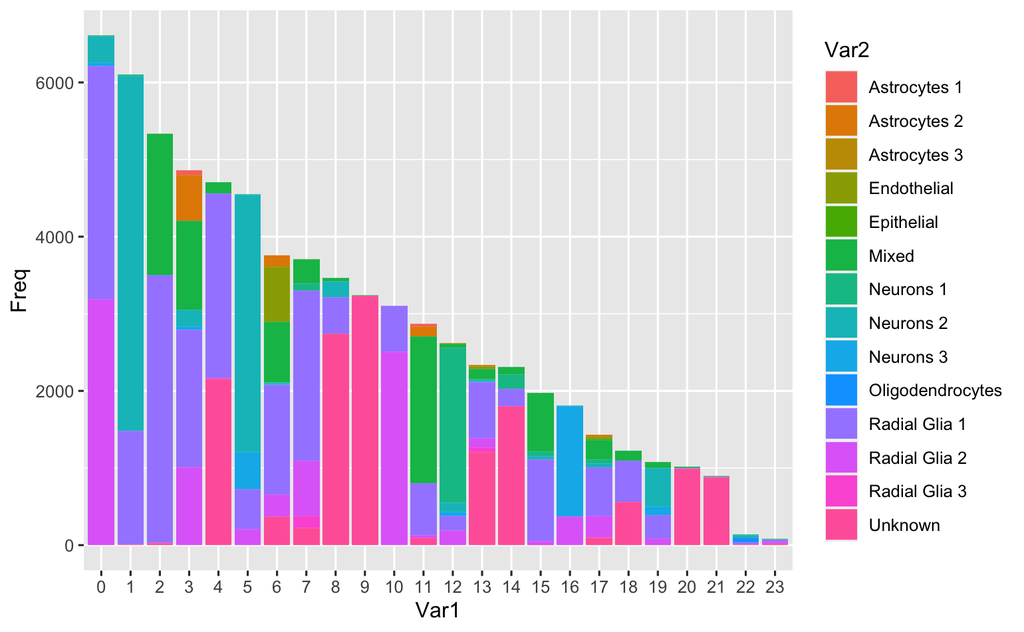

```r
seu <- AddMetaData(seu, metadata = predictions)


# save the Seurat predictions


# make the plots and the prediction tables
t.lables <- as.data.frame(table(seu$seurat_clusters, seu$predicted.id))
pr.t.lables <- as.data.frame(prop.table(table(seu$seurat_clusters, seu$predicted.id)))
t.lables$Freq <- as.double(t.lables$Freq)


# try bar chart
ggplot(t.lables, aes(y = Freq, x = Var1, fill = Var2)) + geom_bar(position = "stack", stat= "identity")
```

```r
# find the top 2 in cell in the group

top.labs <- t.lables  %>% group_by(Var1)  %>% top_n(3, Freq)
top.labs
```

| Var1 | Var2 | Freq |
| --- | --- | --- |
| 10 | Astrocytes 1 | 0 |
| 10 | Astrocytes 2 | 0 |
| 11 | Astrocytes 2 | 129 |
| 10 | Astrocytes 3 | 0 |
| 6 | Endothelial | 716 |
| 10 | Endothelial | 0 |
| 10 | Epithelial | 0 |
| 2 | Mixed | 1836 |
| 3 | Mixed | 1155 |
| 4 | Mixed | 148 |

[output cut: 74 more lines]

```r
top.lab <- t.lables  %>% group_by(Var1)  %>% top_n(1, Freq)
top.lab
```

| Var1 | Var2 | Freq |
| --- | --- | --- |
| 11 | Mixed | 1901 |
| 12 | Neurons 1 | 2011 |
| 1 | Neurons 2 | 4602 |
| 5 | Neurons 2 | 3336 |
| 19 | Neurons 2 | 502 |
| 16 | Neurons 3 | 1428 |
| 22 | Oligodendrocytes | 57 |
| 2 | Radial Glia 1 | 3465 |
| 3 | Radial Glia 1 | 1779 |
| 4 | Radial Glia 1 | 2386 |

[output cut: 14 more lines]

```r
NA
NA
NA
```

Add cell type annotations

```r
png(paste(out_plots,"Bar.FlowJoGated.May10.phenoID.prop.png"),width = 500, height = 400)
ggplot(df, aes(x = GatedCells, y=Freq ,fill = PhenoID.CellTypes)) + geom_bar(position= "fill", stat = "identity")  +
  RotatedAxis() +
  scale_y_continuous(labels = scales::percent_format()) + theme_classic() + theme(text = element_text(size=18),
        axis.text.x = element_text(angle=90, hjust=1, size = 18))  + xlab('Gated cell types') + ylab('Proportion of cell type')  + scale_fill_manual(values = clust.colours) + guides(fill=guide_legend(title="PhenoID cell type annotations"), element_text(size = 18))
dev.off()
```

Read in post sort FC data from June 10th subset of the scRNAseq sample